# Controlling for confounders in penalized regression

Mandy Mejia

2023-09-26

# Controlling for confounders in OLS

When teaching introductory linear regression, one of my favorite topics is adjusted variable plots (also known as “added variable plots”). The basic idea is this: say you want to relate two sets of predictor variables, $\bf X$ and $\bf Z$, to a single response variable $\bf y$. One standard way to do this is through a multiple linear regression model, given in matrix/vector form by:

$${\bf y} = {\bf X}\boldsymbol\beta + {\bf Z}\boldsymbol\gamma +
\boldsymbol\epsilon$$

But let’s say that $\bf Z$ represents some control variables we definitely need to account for (e.g. age, sex), and we want to explore the nature of the relationship between $\bf X$ and $\bf y$, accounting for $\bf Z$. Or imagine we want to fit a model relating $\bf y$ to just $\bf X$, controlling for $\bf Z$ by “regressing it out” beforehand. As it turns out, you can prove mathematically (see below) that if you regress out $\bf Z$ from both $\bf X$ and $\bf y$ then relate the adjusted $\bf y$ to the adjusted $\bf X$, you get the exact same estimate for $\boldsymbol\beta$ as in the multiple linear regression model stated above.

# Simulated Data Example

Here’s an example of this using simulated data. For simplicity, consider the case of a single variable $X$ and single variable $Z$. In this example, both $X$ and $Z$ are correlated with $y$, but there is also strong correlation *between* $X$ and $Z$. So after controlling for $Z$, there will be a weaker relationship between $X$ and $y$. Adjusted variable plots, such as those shown below, allow us to visually explore this relationship.

Generate simulated data:

```r
#generate 3 independent variables X, Y, Z
set.seed(45873)
xyz0 <- matrix(rnorm(100*3), nrow=3, ncol=100)

#induce correlations between X, Y and Z
(cor_xyz <- matrix(c(1, 0.7, 0.85, 0.7, 1, 0.6, 0.85, 0.6, 1), nrow=3))
```

```
##      [,1] [,2] [,3]
## [1,] 1.00  0.7 0.85
## [2,] 0.70  1.0 0.60
## [3,] 0.85  0.6 1.00
```

```r
library(expm)
cor_xyz_sqrt <- sqrtm(cor_xyz)
xyz <- t(cor_xyz_sqrt %*% xyz0)
cor(xyz) #this should be close to cor_xyz
```

```
##           [,1]      [,2]      [,3]
## [1,] 1.0000000 0.6822354 0.8799130
## [2,] 0.6822354 1.0000000 0.6422735
## [3,] 0.8799130 0.6422735 1.0000000
```

```r
#define X, Y, Z
X <- xyz[,1]
Y <- xyz[,2]
Z <- xyz[,3]
```

Plot the marginal relationships between all three variables:

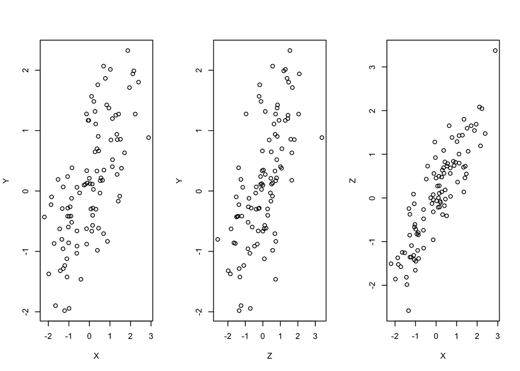

```r
#plot marginal relationships
par(mfrow=c(1,3))
plot(X, Y)
plot(Z, Y)
plot(X, Z)
```

Plot the marginal vs. adjusted relationship between $X$ and $Y$:

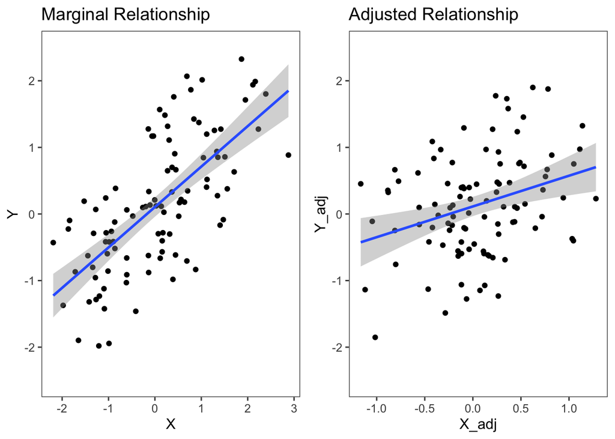

```r
#adjust both X and Y for Z, adding back in the mean
Y_adj <- residuals(lm(Y ~ Z)) + mean(Y)
X_adj <- residuals(lm(X ~ Z)) + mean(X)

library(ggplot2)
library(ggthemes)
library(gridExtra)
p1 <- qplot(X, Y) + geom_smooth(method='lm') + ggtitle('Marginal Relationship') + theme_few() + ylim(-2.5, 2.5)
p2 <- qplot(X_adj, Y_adj) + geom_smooth(method='lm') + ggtitle('Adjusted Relationship') + theme_few() + ylim(-2.5, 2.5)
grid.arrange(p1, p2, nrow=1)
```

The marginal relationship plot paints an overly optimistic picture of the relationship between $X$ and $y$ if $Z$ is going to be accounted for in the model. By contrast, the adjusted relationship plot adjusts for $Z$ so we can get an accurate visual picture of the relationship between $X$ and $y$, accounting for $Z$.

We might also see non-linear relationships between $x$ and $y$, which we should build into the model to avoid a misspecified model. Here’s a simple simulated example where $y$ is related to $x$ in a non-linear way

```r
#use the correlated x and z from above
#simulate y = beta0 + beta1*x^2 + gamma*z
beta0 <- 2
beta1 <- -2
gamma <- 5
Y <- beta0 + beta1*X^2 + gamma*Z + rnorm(100, mean = 0, sd = 0.1)
```

The true relationship between $x$ and $y$, for a fixed value of $z$, looks like this:

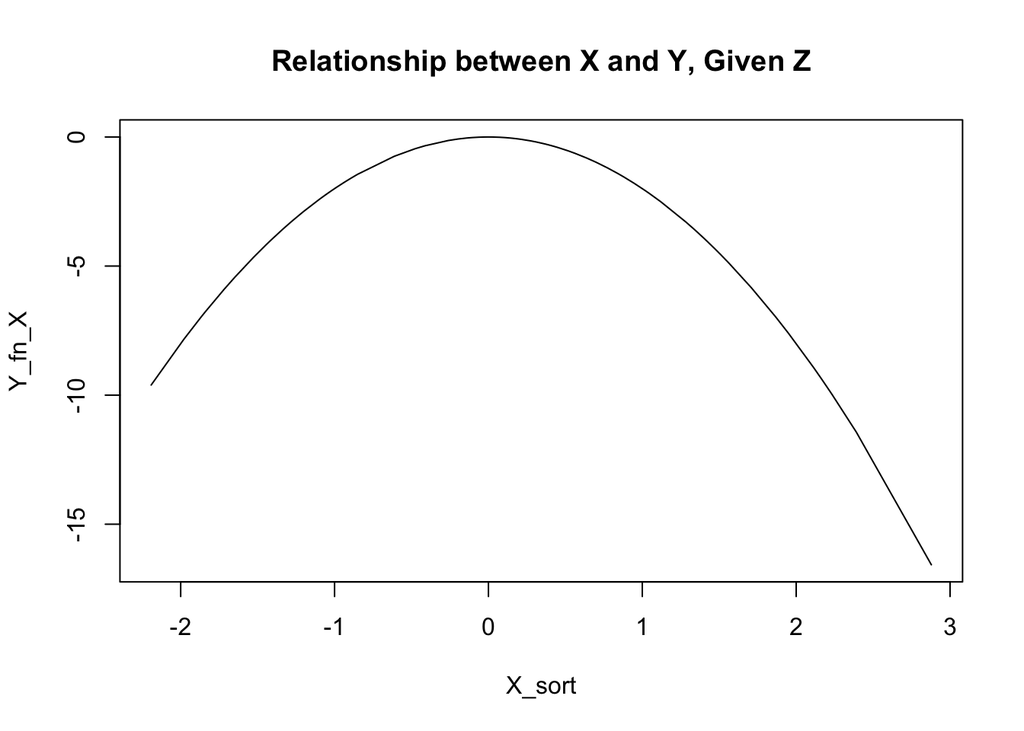

```r
X_sort <- sort(X)
Y_fn_X <- beta1*X_sort^2
plot(X_sort, Y_fn_X, type='l', main='Relationship between X and Y, Given Z')
```

If we just visualize the marginal relationship between X and Y, this is not at all clear. But if we first adjust for Z, we start to see clear non-linear patterns. With this knowledge, we can incorporate non-linear terms in the model to provide enough flexiblity to capture non-linear associations.

Plot the marginal relationships between all three variables:

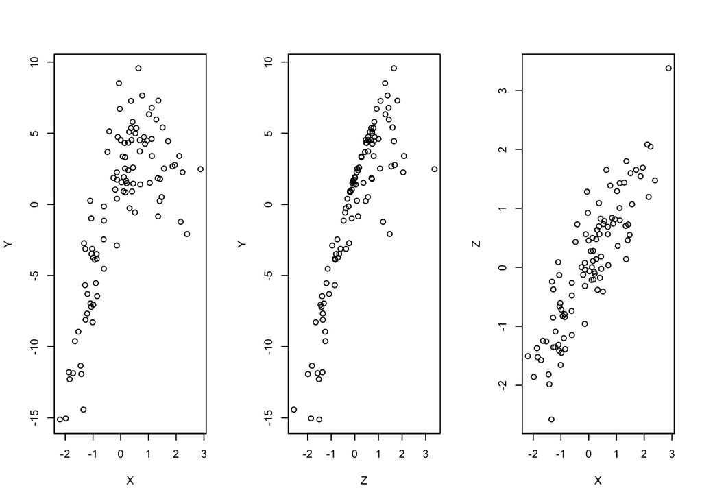

```r
#plot marginal relationships
par(mfrow=c(1,3))
plot(X, Y)
plot(Z, Y)
plot(X, Z)
```

Plot the marginal vs. adjusted relationship between $x$ and $y$:

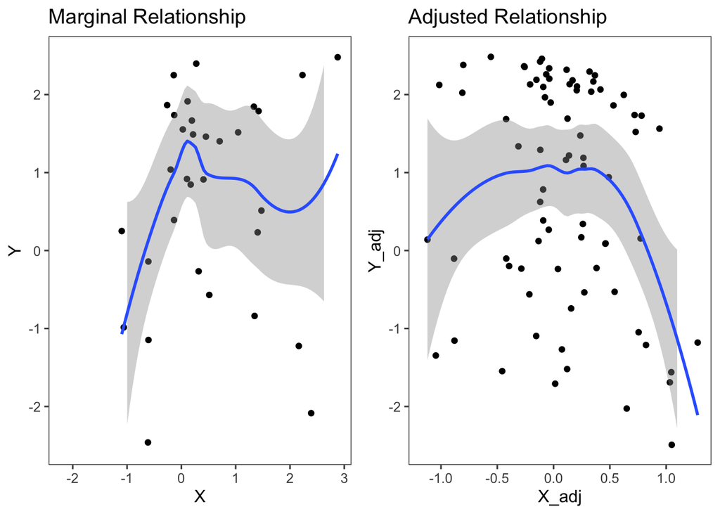

```r
#adjust both X and Y for Z, adding back in the mean
Y_adj <- residuals(lm(Y ~ Z)) + mean(Y)
X_adj <- residuals(lm(X ~ Z)) + mean(X)

p1 <- qplot(X, Y) + geom_smooth() + ggtitle('Marginal Relationship') + theme_few() + ylim(-2.5, 2.5)
p2 <- qplot(X_adj, Y_adj) + geom_smooth() + ggtitle('Adjusted Relationship') + theme_few() + ylim(-2.5, 2.5)
grid.arrange(p1, p2, nrow=1)
```

# Proof of Adjusted Variables in OLS

To show this mathematically, first we must introduce some formalities. Let $\bf H$ denote the “hat matrix” when the design matrix is $\bf Z$, namely

$${\bf H} = {\bf Z}({\bf Z'Z})^{-1}{\bf Z'}$$

Recall that $\bf H$ “puts the hat on” $\bf y$ when predicting $\bf y$ from $\bf Z$, i.e. $\hat{\bf y} = \bf Hy$. The residuals are given by $\hat{\bf y} - {\bf y} = \bf (I-H)y$, which are what we mean when we say “$\bf y$ adjusted for $\bf Z$”, which we are calling $\bf y^*$. So $\bf y^* = (I-H)y$, and $\bf X^* = (I-H)X$, where in both cases $\bf H$ is the hat matrix when the design matrix is $\bf Z$.

Now that we have our adjusted variables $\bf y^*$ and $\bf X^*$, we can relate them through the model

$${\bf y}^* = {\bf X}^*\boldsymbol\beta + \boldsymbol\epsilon$$
We can show mathematically that the OLS estimate for $\boldsymbol\beta$ in this model is exactly equal to the OLS estimate for $\boldsymbol \beta$ in the earlier model with $\bf X$ and $\bf Z$. First, let’s work out the OLS estimate for $\boldsymbol \beta$ in this model relating $\bf y^*$ to $\bf X^*$. We will use the fact that $\bf I - H$ is symmetric and idempotent, meaning that $\bf (I - H)(I - H) = (I - H)$.

$$\hat{\boldsymbol\beta}^* = ({{\bf X}^*}'{\bf X}^*)^{-1}{{\bf
X}^*}'{{\bf y}^*} = ({\bf X}'({\bf I - H}){\bf X})^{-1}{{\bf
X}}'({\bf I - H}){{\bf y}}$$

That was the easy part. :) Now let’s work out the OLS estimate for $\boldsymbol \beta$ in the earlier model relating $\bf y$ to $\bf X$ and $\bf Z$.

$$\begin{pmatrix} \hat{\boldsymbol\beta} \\ \hat{\boldsymbol\gamma}
\end{pmatrix}
= ([{\bf X}{\bf Z}]'[{\bf X}{\bf Z}])^{-1}[{\bf X}{\bf Z}]'{\bf
y}
= \begin{pmatrix} {\bf X}'{\bf X} & {\bf X}'{\bf Z} \\
{\bf Z}'{\bf X} & {\bf Z}'{\bf Z} \end{pmatrix}^{-1}
\begin{pmatrix}{\bf X}'{\bf y} \\ {\bf Z}'{\bf y} \end{pmatrix}
=: {\bf A}\begin{pmatrix}{\bf X}'{\bf y} \\ {\bf Z}'{\bf y}
\end{pmatrix}$$
Since we are mainly interested in $\boldsymbol\beta$, we need to work out the (1,1) and (1,2) blocks of $\bf A$, the inverse of the block matrix that appears above. Using standard formulas for block matrix inverses, we can obtain

$$\begin{align*}
\hat{\boldsymbol\beta} &= {\bf A}_{(1,1)}{\bf X}'{\bf y} + {\bf
A}_{(1,2)}{\bf Z}'{\bf y} \\
&= ({\bf X}'{\bf X} - {\bf X}'{\bf Z}({\bf Z}'{\bf
Z})^{-1}{\bf Z}'{\bf X})^{-1}{\bf X}'{\bf y} - ({\bf X}'{\bf
X} - {\bf X}'{\bf Z}({\bf Z}'{\bf Z})^{-1}{\bf Z}'{\bf
X})^{-1}{\bf X}'{\bf Z}({\bf Z}'{\bf Z})^{-1}{\bf Z}'{\bf y}
\\
&= ({\bf X}'{\bf X} - {\bf X}'{\bf H}{\bf X})^{-1}{\bf
X}'{\bf y} - ({\bf X}'{\bf X} - {\bf X}'{\bf H}{\bf
X})^{-1}{\bf X}'{\bf H}{\bf y} \\
&= ({\bf X}'{\bf X} - {\bf X}'{\bf H}{\bf X})^{-1}({\bf
X}'{\bf y} - {\bf X}'{\bf H}{\bf y})\\
&= ({\bf X}({\bf I - H}){\bf X})^{-1}({\bf X}'({\bf I - H}){\bf
y})\\
&= ({\bf X}^*{\bf X}^*)^{-1}({\bf X^*}'{\bf y}^*)\\
\end{align*}$$

Voila, it works!

# Proof of Adjusted Variables in Penalized Regression

If we fit a model relating a high-dimensional set of predictors $\bf X$ to $\bf y$ with either ridge or LASSO, the estimator for $\beta$ is given by

$$\hat{\boldsymbol\beta} = ({{\bf X}}'{\bf X} + \lambda{\bf
I})^{-1}{{\bf X}}'{{\bf y}}$$
where $\lambda$ is a penalty parameter that is typically determined via cross-validation. If we also include confounders $\bf Z$ in the model, we can avoid including them in the penalization by setting $\lambda = 0$ for those variables. So our penalty matrix, rather than $\lambda \bf I$, becomes a block-diagonal matrix with $\lambda \bf I$ defining the upper-left block and zeros everywhere else.

As before, we can work out the estimate for $\boldsymbol\beta$ in the case of a penalty on $\bf X$:

$$\begin{align*}
\begin{pmatrix} \hat{\boldsymbol\beta}^R \\ \hat{\boldsymbol\gamma}^R
\end{pmatrix}
&= \left\{[{\bf X}{\bf Z}]'[{\bf X}{\bf Z}] +
\begin{pmatrix}\lambda{\bf I}_p^{-1} & {\bf 0} \\ {\bf 0} & {\bf
0} \end{pmatrix}\right\}^{-1}
[{\bf X}{\bf Z}]'{\bf y} \\
&= \left\{\begin{pmatrix} {\bf X}'{\bf X} & {\bf X}'{\bf
Z} \\
{\bf Z}'{\bf X} & {\bf Z}'{\bf Z} \end{pmatrix} +
\begin{pmatrix}\lambda{\bf I}_p^{-1} & {\bf 0} \\ {\bf 0} & {\bf
0} \end{pmatrix}\right\}^{-1}
\begin{pmatrix}{\bf X}'{\bf y} \\ {\bf Z}'{\bf y} \end{pmatrix}
\\
&= \begin{pmatrix} {\bf X}'{\bf X} + \lambda{\bf I}_p & {\bf
X}'{\bf Z} \\
{\bf Z}'{\bf X} & {\bf Z}'{\bf Z} \end{pmatrix} ^{-1}
\begin{pmatrix}{\bf X}'{\bf y} \\ {\bf Z}'{\bf y} \end{pmatrix}
\end{align*}$$

Again we can use block matrix inverse formulas to obtain the estimator for $\boldsymbol\beta$. Skipping some steps this time, we obtain

$$\begin{align*}
\hat{\boldsymbol\beta}^R
&= \left(({\bf X}'{\bf X} + \lambda{\bf I}_p) - {\bf X}'{\bf
Z}({\bf Z}'{\bf Z})^{-1}{\bf Z}'{\bf X}\right)^{-1}({\bf
X}'{\bf y} - {\bf X}'{\bf Z}({\bf Z}'{\bf Z})^{-1}{\bf
Z}'{\bf y}) \\
&= \left(({\bf X}'{\bf X} + \lambda{\bf I}_p) - {\bf X}'{\bf
H}{\bf X}\right)^{-1}({\bf X}'{\bf y} - {\bf X}'{\bf H}{\bf y})
\\
&= \left(({\bf X}'{\bf X} - {\bf X}'{\bf H}{\bf X} +
\lambda{\bf I}_p\right)^{-1}({\bf X}'{\bf y} - {\bf X}'{\bf
H}{\bf y}) \\
&= \left(({\bf X}'({\bf I - H}){\bf X} + \lambda{\bf
I}_p\right)^{-1}({\bf X}'({\bf I - H}){\bf y}) \\
&= \left(({\bf X^*}'{\bf X^*} + \lambda{\bf
I}_p\right)^{-1}({\bf X^*}'{\bf y^*})
\end{align*}$$

Success! This estimator for $\boldsymbol\beta$ is the same as what we would get if we related $\bf y^*$ ($\bf y$ adjusted for $\bf Z$) against $\bf X^*$ ($\bf X$ adjusted for $\bf Z$) with a ridge or LASSO penalty. So the theory of adjusted variable plots in OLS holds for penalized regression methods like LASSO and ridge.

## Proof of adjusted variables in OLS

To introduce some formalities, let $\bf H$ denote the “hat matrix” when the design matrix is $\bf Z$, namely

$${\bf H} = {\bf Z}({\bf Z'Z})^{-1}{\bf Z'}$$

Recall that $\bf H$ “puts the hat on” $\bf y$ when predicting $\bf y$ from $\bf Z$, i.e. $\hat{\bf y} = \bf Hy$. The residuals are given by $\hat{\bf y} - {\bf y} = ({\bf I-H}){\bf y}$, which are what we mean when we say “$\bf y$ adjusted for $\bf Z$”, which here we are calling $\tilde{\bf y}$. So $\tilde{\bf y}= ({\bf I-H}){\bf y}$, and $\tilde{\bf X}= ({\bf I-H}){\bf X}$, where in both cases $\bf H$ is the hat matrix when the design matrix is $\bf Z$.

Now that we have our adjusted variables $\tilde{\bf y}$ and $\tilde{\bf X}$, we can relate them through the model

$$\tilde{\bf y} = \tilde{\bf X}\boldsymbol\beta + \boldsymbol\epsilon$$

We can show mathematically that the OLS estimate for $\boldsymbol\beta$ in this model is exactly equal to the OLS estimate for $\boldsymbol\beta$ in the earlier model with $\bf X$ and $\bf Z$. First, let’s work out the OLS estimate for $\boldsymbol\beta$ in this model relating $\tilde{\bf y}$ to $\tilde{\bf X}$. We will use the fact that $\bf I - H$ is symmetric and idempotent, meaning that $(\bf I - H)(\bf I - H) = (\bf I - H)$.

$$\tilde{\boldsymbol\beta} = ({\tilde{\bf X}}'\tilde{\bf
X})^{-1}{\tilde{\bf X}}'{\tilde{\bf y}} = ({\bf X}'({\bf I -
H}){\bf X})^{-1}{{\bf X}}'({\bf I - H}){{\bf y}}$$

That was the easy part. :) Now let’s work out the OLS estimate for $\boldsymbol\beta$ in the earlier model relating $\bf y$ to $\bf X$ and $\bf Z$. The full design matrix in this model is $[\bf X \bf Z]$, and the full coefficient vector is $(\boldsymbol\beta' \boldsymbol\gamma')'$, so we can write the standard OLS estimator as:

$$\begin{pmatrix} \hat{\boldsymbol\beta} \\ \hat{\boldsymbol\gamma}
\end{pmatrix}
= ([{\bf X}{\bf Z}]'[{\bf X}{\bf Z}])^{-1}[{\bf X}{\bf Z}]'{\bf
y}
= \begin{pmatrix} {\bf X}'{\bf X} & {\bf X}'{\bf Z} \\
{\bf Z}'{\bf X} & {\bf Z}'{\bf Z} \end{pmatrix}^{-1}
\begin{pmatrix}{\bf X}'{\bf y} \\ {\bf Z}'{\bf y} \end{pmatrix}
=: {\bf A}\begin{pmatrix}{\bf X}'{\bf y} \\ {\bf Z}'{\bf y}
\end{pmatrix}$$

Since we are mainly interested in $\boldsymbol\beta$, we need to work out the $(1,1)$ and $(1,2)$ blocks of the matrix $\bf A$ defined above. Using standard formulas for block matrix inverses, we can obtain

$$\begin{align*}
\hat{\boldsymbol\beta} &= {\bf A}_{(1,1)}{\bf X}'{\bf y} + {\bf
A}_{(1,2)}{\bf Z}'{\bf y} \\
&= ({\bf X}'{\bf X} - {\bf X}'{\bf Z}({\bf Z}'{\bf
Z})^{-1}{\bf Z}'{\bf X})^{-1}{\bf X}'{\bf y} - ({\bf X}'{\bf
X} - {\bf X}'{\bf Z}({\bf Z}'{\bf Z})^{-1}{\bf Z}'{\bf
X})^{-1}{\bf X}'{\bf Z}({\bf Z}'{\bf Z})^{-1}{\bf Z}'{\bf y}
\\
&= ({\bf X}'{\bf X} - {\bf X}'{\bf H}{\bf X})^{-1}{\bf
X}'{\bf y} - ({\bf X}'{\bf X} - {\bf X}'{\bf H}{\bf
X})^{-1}{\bf X}'{\bf H}{\bf y} \\
&= ({\bf X}'{\bf X} - {\bf X}'{\bf H}{\bf X})^{-1}({\bf
X}'{\bf y} - {\bf X}'{\bf H}{\bf y})\\
&= ({\bf X}({\bf I - H}){\bf X})^{-1}({\bf X}'({\bf I - H}){\bf
y})\\
&= (\tilde{\bf X}'\tilde{\bf X})^{-1}(\tilde{\bf
X}'\tilde{\bf y})\\
\end{align*}$$

Voila, it works!

## Proof of adjusted variables in penalized regression

In many applications including my personal research, $\bf X$ is high-dimensional with the number of columns/variables $p$ (much) greater than the number of rows/observations $n$. In this case, it’s common to use penalized regression techniques like ridge regression or LASSO. Does the result above hold in this context? That is, if we regress out confounders $\bf Z$ from $\bf X$ and from $\bf y$ beforehand, do we obtain the same estimates for the beta coefficients on $\bf X$, versus including $\bf Z$ in the model?

If we fit a model relating a high-dimensional set of predictors $\bf X$ to $\bf y$ with either ridge or LASSO, the estimator for $\boldsymbol\beta$ is given by

$$\hat{\boldsymbol\beta} = ({{\bf X}}'{\bf X} + \lambda{\bf
I})^{-1}{{\bf X}}'{{\bf y}},$$

where $\boldsymbol\lambda$ is a penalty parameter that is typically determined via cross-validation. If we also include confounders $\bf Z$ in the model, we can avoid including them in the penalization by setting $\boldsymbol\lambda=0$ for those variables. So our penalty matrix, rather than $\boldsymbol\lambda$I, becomes a block-diagonal matrix with $\boldsymbol\lambda{\bf I}$ defining the upper-left block and zeros everywhere else.

As before, we can work out the estimate for $\boldsymbol\beta$ in the case of a penalty on $\bf X$:

$$\begin{align*}
\begin{pmatrix} \hat{\boldsymbol\beta}^R \\ \hat{\boldsymbol\gamma}^R
\end{pmatrix}
&= \left\{[{\bf X}{\bf Z}]'[{\bf X}{\bf Z}] +
\begin{pmatrix}\lambda{\bf I}_p^{-1} & {\bf 0} \\ {\bf 0} & {\bf
0} \end{pmatrix}\right\}^{-1}
[{\bf X}{\bf Z}]'{\bf y} \\
&= \left\{\begin{pmatrix} {\bf X}'{\bf X} & {\bf X}'{\bf
Z} \\
{\bf Z}'{\bf X} & {\bf Z}'{\bf Z} \end{pmatrix} +
\begin{pmatrix}\lambda{\bf I}_p^{-1} & {\bf 0} \\ {\bf 0} & {\bf
0} \end{pmatrix}\right\}^{-1}
\begin{pmatrix}{\bf X}'{\bf y} \\ {\bf Z}'{\bf y} \end{pmatrix}
\\
&= \begin{pmatrix} {\bf X}'{\bf X} + \lambda{\bf I}_p & {\bf
X}'{\bf Z} \\
{\bf Z}'{\bf X} & {\bf Z}'{\bf Z} \end{pmatrix} ^{-1}
\begin{pmatrix}{\bf X}'{\bf y} \\ {\bf Z}'{\bf y} \end{pmatrix}.
\end{align*}$$

Again we can use block matrix inverse formulas to obtain the estimator for $\boldsymbol\beta$. Skipping some steps this time, we obtain

$$\begin{align*}
\hat{\boldsymbol\beta}^R
&= \left(({\bf X}'{\bf X} + \lambda{\bf I}_p) - {\bf X}'{\bf
Z}({\bf Z}'{\bf Z})^{-1}{\bf Z}'{\bf X}\right)^{-1}({\bf
X}'{\bf y} - {\bf X}'{\bf Z}({\bf Z}'{\bf Z})^{-1}{\bf
Z}'{\bf y}) \\
&= \left(({\bf X}'{\bf X} + \lambda{\bf I}_p) - {\bf X}'{\bf
H}{\bf X}\right)^{-1}({\bf X}'{\bf y} - {\bf X}'{\bf H}{\bf y})
\\
&= \left(({\bf X}'{\bf X} - {\bf X}'{\bf H}{\bf X} +
\lambda{\bf I}_p\right)^{-1}({\bf X}'{\bf y} - {\bf X}'{\bf
H}{\bf y}) \\
&= \left(({\bf X}'({\bf I - H}){\bf X} + \lambda{\bf
I}_p\right)^{-1}({\bf X}'({\bf I - H}){\bf y}) \\
&= \left((\tilde{\bf X}'\tilde{\bf X} + \lambda{\bf
I}_p\right)^{-1}(\tilde{\bf X}'\tilde{\bf y})
\end{align*}$$

Success! This estimator for $\boldsymbol\beta$ is the same as what we would get if we related $\tilde{\bf y}$ ($\bf y$ adjusted for $\bf Z$) against $\tilde{\bf X}$ ($\bf X$ adjusted for $\bf Z$) with a ridge or LASSO penalty. So the theory of adjusted variable plots in OLS holds for penalized regression methods like LASSO and ridge.

## Take home message

When “adjusting for” confounding variables prior to fitting a model focusing only on the variables of interest, it is important to regress the confounders out from both $\bf X$ and $\bf y$! It is somewhat common to see $\bf Z$ only regressed from $\bf y$, disregarding the potential influence of $\bf Z$ on $\bf X$. This is a process known as “sequential processing” that can have unintended consequences. In the case of *prediction* of $\bf y$ based on $\bf X$, failing to adjust $\bf X$ for $\bf Z$ as well can lead to **attenuated prediction coefficients** and **worse prediction accuracy**. Whether you are using standard OLS or penalized regression in a high-dimensional setting, if you adjust both $\bf y$ and $\bf X$ for $\bf Z$, you can rest assured that it is fully equivalent to including $\bf Z$ as a confounder in your model.